# Advanced topics

X. Pouwels

2021-01-21

# Install and load packages

First, the required packages need to be installed and loaded.

```r
rm(list = ls()) # clear environment
options(scipen = 999)
# Install
#install.packages("fitdistrplus")
#install.packages("mvtnorm")

# Load
library(fitdistrplus)
library(mvtnorm)
library(stats)
library(doSNOW)
library(parallel)
library(ggplot2)
```

# Uncertainty surrounding hyperparameters of the distribution (e.g. gamma)

The approach described above may be sufficient when you want to capture parameter uncertainty at the population level. However, in a patient-level simulation, you may be able to captue both first-order (stochastic) uncertainty and second-order (parameter) uncertainty. To do so, you need to perform a Monte Carlo simulation of the hyperparameters of a distribution (which corresponds to capture parameter uncertainty), and then draw a random value from the newly defined distribution for each simulated agent/patient (which corresponds to capture stochastic uncertainty). The hyperparameters of a distribution can be varied by using a multivariate normal distribution or bootstrapping, as illustrated below. These approaches are described in [Degeling et al. - 2017](https://bmcmedresmethodol.biomedcentral.com/articles/10.1186/s12874-017-0437-y).

## Using multivariate normal distribution

```r
data("groundbeef") #load data
dist_gamma <- fitdist(groundbeef$serving, distr = "gamma") # fit gamma distribution as in 'Distributions' example
dist_gamma$estimate # show fitted estimates
```

```
##      shape       rate
## 4.00825257 0.05441911
```

```r
dist_gamma$cor # show correlation coefficient between parameters
```

```
##           shape      rate
## shape 1.0000000 0.9384381
## rate  0.9384381 1.0000000
```

```r
dist_gamma$vcov # show covariance matrix between parameters
```

```
##             shape          rate
## shape 0.116510296 0.00158094254
## rate  0.001580943 0.00002435884
```

```r
m_params <- rmvnorm(n = 1000, mean = dist_gamma$estimate, sigma = dist_gamma$vcov) # $estimate is the vector of mean value of the parameters, $vcov is the variance-covariance matrix of the parameters of the distribution

head(m_params)# view first random parameters
```

```
##         shape       rate
## [1,] 4.301110 0.05571274
## [2,] 4.427867 0.05930057
## [3,] 3.829779 0.05308996
## [4,] 4.017891 0.05509662
## [5,] 3.909166 0.05295309
## [6,] 4.476027 0.06354076
```

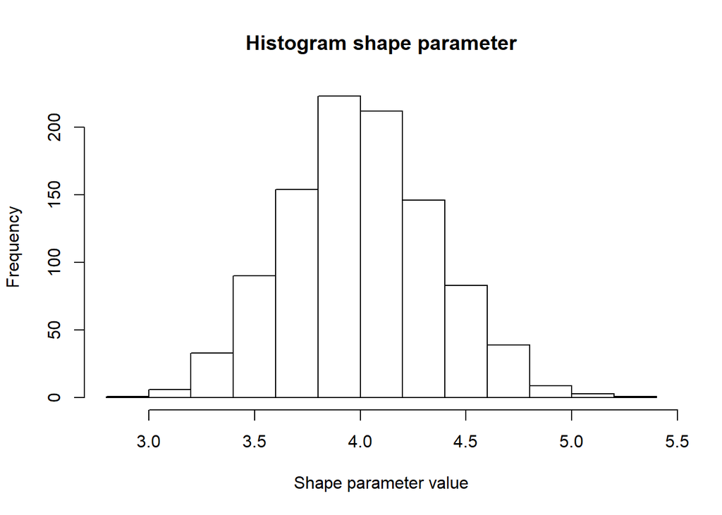

```r
hist(m_params[,"shape"], main = "Histogram shape parameter", xlab = "Shape parameter value") # check distribution parameter
```

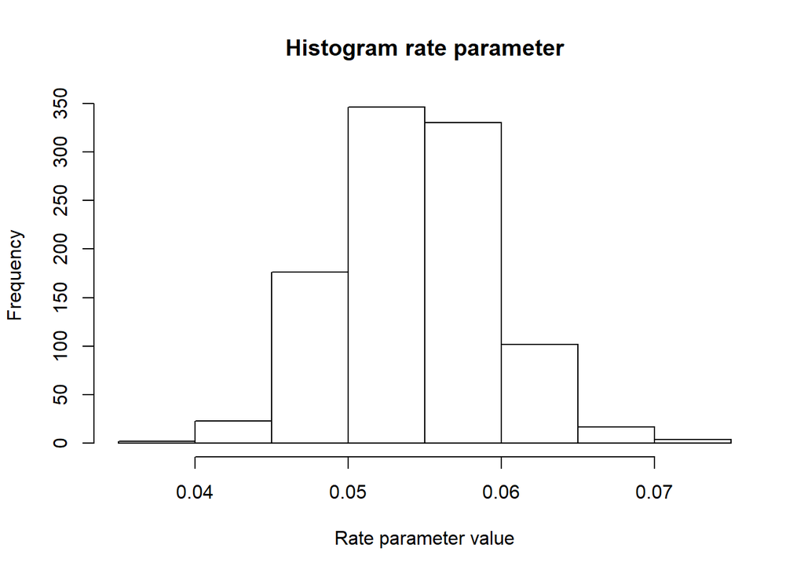

```r
hist(m_params[,"rate"], main = "Histogram rate parameter", xlab = "Rate parameter value") # check distribution parameter
```

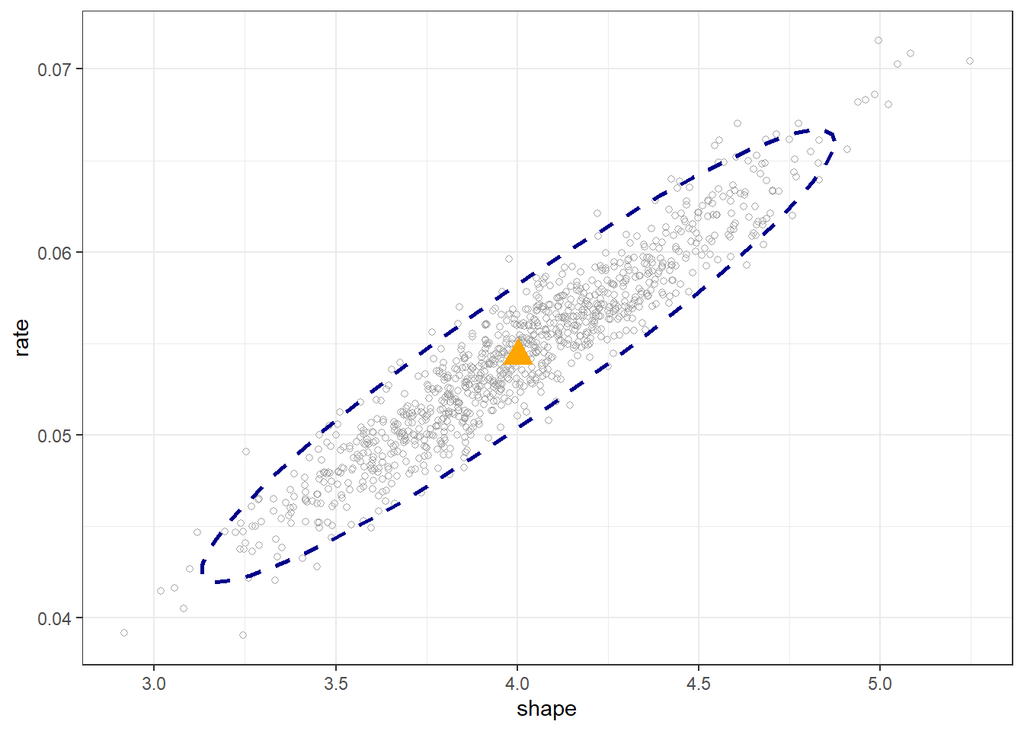

```r
#plot(m_params[,"shape"], m_params[,"rate"])

# plot rate vs shape
ggplot(aes(x = shape, y = rate), data = as.data.frame(m_params)) +
  geom_point(colour = "darkgrey", shape = 1) +
  stat_ellipse(type = "norm",#assumes multivariate normal distribution, 95%CI
               colour = "darkblue",
               level = 0.95, size = 1,
               lty = 2) +
   geom_point(aes(x = mean(shape), y = mean(rate)),
              colour = "orange",
              size = 5,
              shape = 17) +
  theme_bw()
```

## Using non-parametric bootstrapping

```r
l_params_2 <- bootdist(f = dist_gamma,
                       bootmethod = "nonparam",
                       niter = 1000,
                       parallel = "snow",
                       ncpus = detectCores() - 1) # perform 1000 non-parametric boostrapping, using parallelisation (all cores except 1)

head(l_params_2$estim) # show parameters fitted to first  bootstrapped samples
```

```
##      shape       rate
## 1 4.250398 0.05592809
## 2 3.737598 0.05020611
## 3 3.779776 0.05322059
## 4 3.979948 0.05454606
## 5 4.585676 0.06076116
## 6 4.196148 0.05362611
```

```r
summary(l_params_2$estim) # show summary statistics of the parameters
```

```
##      shape            rate
##  Min.   :3.112   Min.   :0.04349
##  1st Qu.:3.818   1st Qu.:0.05199
##  Median :4.034   Median :0.05469
##  Mean   :4.047   Mean   :0.05492
##  3rd Qu.:4.252   3rd Qu.:0.05773
##  Max.   :5.330   Max.   :0.07189
```

```r
l_params_2$fitpart$cor # show correlation matrix between parameters
```

```
##           shape      rate
## shape 1.0000000 0.9384381
## rate  0.9384381 1.0000000
```

```r
l_params_2$fitpart$vcov # show variance-covariance matrix between parameters
```

```
##             shape          rate
## shape 0.116510296 0.00158094254
## rate  0.001580943 0.00002435884
```

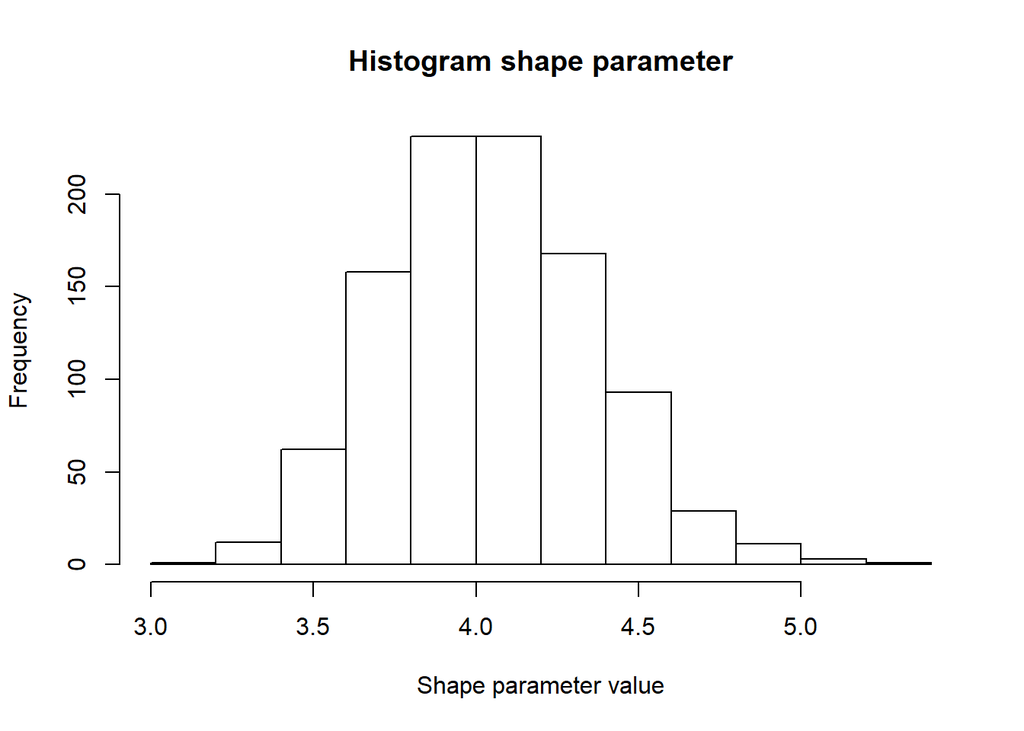

```r
hist(l_params_2$estim[,"shape"], main = "Histogram shape parameter", xlab = "Shape parameter value") # check distribution parameter
```

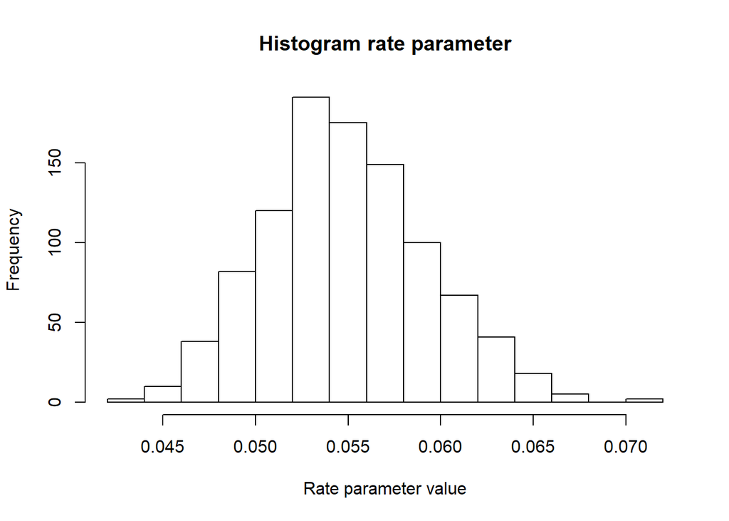

```r
hist(l_params_2$estim[,"rate"], main = "Histogram rate parameter", xlab = "Rate parameter value") # check distribution parameter
```

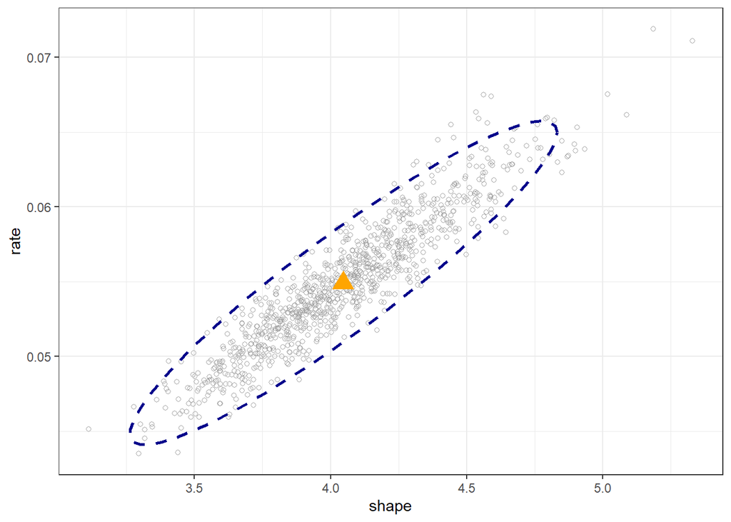

```r
# plot rate vs shape
ggplot(aes(x = shape, y = rate), data = as.data.frame(l_params_2$estim)) +
  geom_point(colour = "darkgrey", shape = 1) +
  stat_ellipse(type = "norm",#assumes multivariate normal distribution, 95%CI
               colour = "darkblue",
               level = 0.95, size = 1,
               lty = 2) +
   geom_point(aes(x = mean(shape), y = mean(rate)),
              colour = "orange",
              size = 5,
              shape = 17) +
  theme_bw()
```

## Using alternative parameters for random draw

In a probabilistic analysis, you will have to loop over all these 1,000 (in this example) alternative (probabilistic) parameter values.

```r
rgamma(1, shape = m_params[3, "shape"], rate = m_params[3, "rate"]) # 1 random value, using the third alternative set of parameters
```

```
## [1] 49.94893
```

```r
rgamma(1, shape = l_params_2$estim[301, "shape"], rate = l_params_2$estim[301, "rate"]) # 1 random value, using the 301th alternative set of parameters
```

```
## [1] 45.1024
```

### Impact of varying the hyperparameters of the distribution

These two plots illustrate the range of values that are used in the simulation when one is not and is varying the hyperparameter of a gamma distribution.

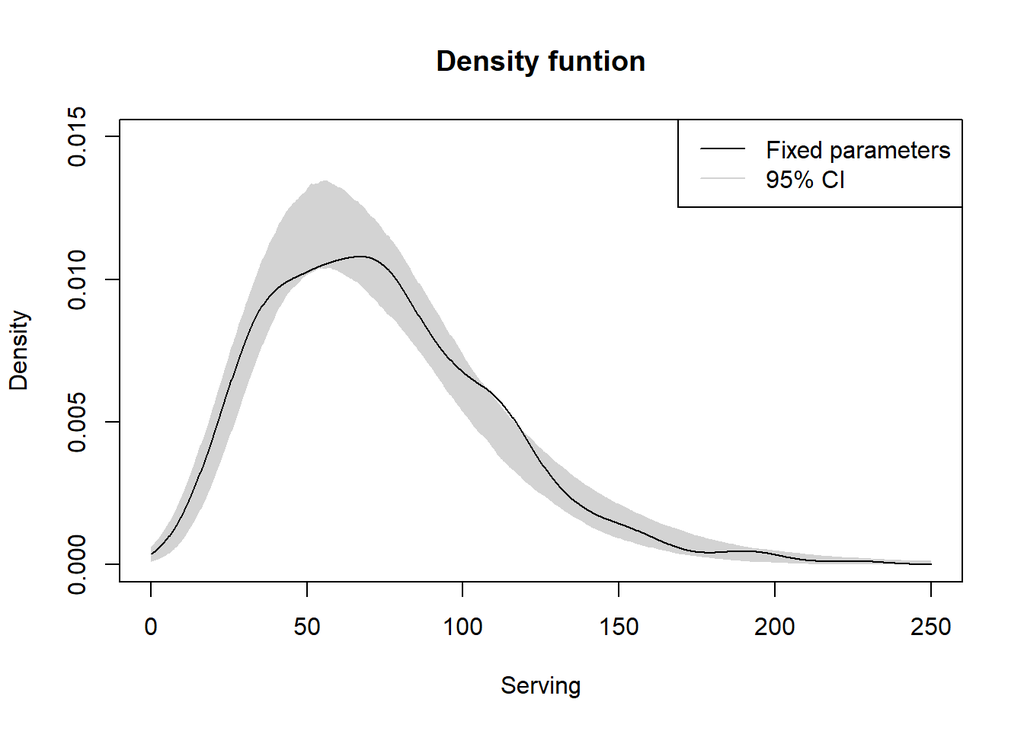

```r
v_rgamma_single <- rgamma(1000, shape = dist_gamma$estimate["shape"], rate = dist_gamma$estimate["rate"]) # drawing 1,000 values of the previously defined gamma distribution, hyperparameter uncertainty ignored
# drawing 1,000 values of the 1,0000 gamma distribution of which the hyperparameter are varied

v_rgamma_var <- matrix(NA, ncol = 1000, nrow = 1000)
for(i in c(1:1000)){
  v_rgamma_var[i,] <- rgamma(1000, shape = m_params[i, "shape"], rate = m_params[i, "rate"])
}

l_res_dens <- apply(v_rgamma_var, 1, function (x) density(x, n= 1000, from = 0, to = 250)) # determine density function of the 1,000 gamma distributions

m_y_dens <- sapply(1:1000, function(x) l_res_dens[[x]]$y) # extract y values of the 1,000 density functions

m_y_CI <- apply(m_y_dens, 1, function (x) quantile(x, probs = c(0.025, 0.975))) # extract 2.5% and 97.5% quantiles per x-values of the density functions

#plot 95%CI of 1,000 density functions of gamma distributions, and the density function of the single gamma distribution

plot(x = l_res_dens[[1]]$x, y = l_res_dens[[1]]$y, type = "l", lwd = 1, col = "white", main = "Density funtion", ylim = c(0,0.015), xlab = "Serving", ylab = "Density");
polygon(c(l_res_dens[[1]]$x, rev(l_res_dens[[1]]$x)), c(m_y_CI[1,], rev(m_y_CI[2,])), col = "lightgray", border = NA);
lines(density(v_rgamma_single,  n= 1000, from = 0, to = 250), col = "black")
legend("topright",                    # Add legend to plot
       legend = c("Fixed parameters", "95% CI"),
       col = c("black", "lightgray"),
       lty = 1)
```